# 4051 Rouleurs 2016 TDF Recap

01 July 2017

### Introduction

With the 2017 Tour De France set to commence wheels rolling tonight, it’s perhaps a good time to reflect on our performance twelve months earlier.

The new product plastic wrap was off by the time our valiant Velogamers lined up for the second Grand Tour of 2016. Numbers and anticipation had increased with the stage set for a gloves-off battle for Veolgames glory.

With 14 teams there was the opportunity for 14 unique teams and 126 riders in total. However the short list of favoured athletes in each category ultimately led us to select our squads from only 59 of the 198 riders starting the Tour at the Mont Saint-Michel island monastery on the 2nd of July, 2016.

| Rider | Times Selected |
| --- | --- |
| Nairo Quintana | 8 |
| Christopher Froome | 7 |
| Richie Porte | 7 |
| Simon Gerrans | 7 |
| André Greipel | 4 |
| Luke Durbridge | 4 |
| Pierre Rolland | 4 |
| Rohan Dennis | 4 |
| Tom Dumoulin | 4 |
| Tony Martin | 4 |
| Adam Hansen | 3 |
| Daniel Martin | 3 |

The most popular rider was Columbian Nairo Quintana with 8 of us selecting Nairoman to do battle on French roads.

### Top Ten Riders

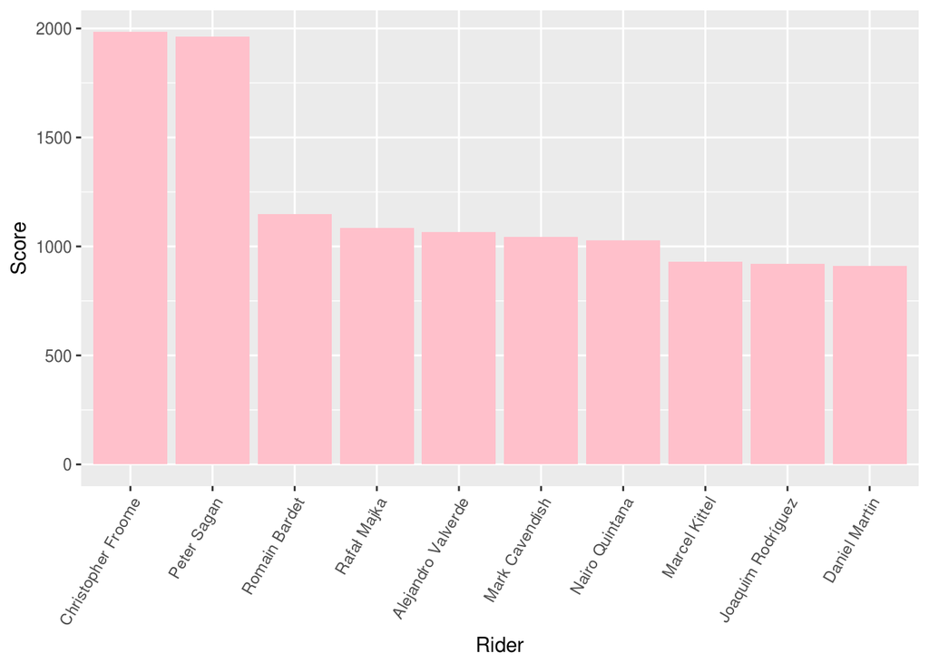

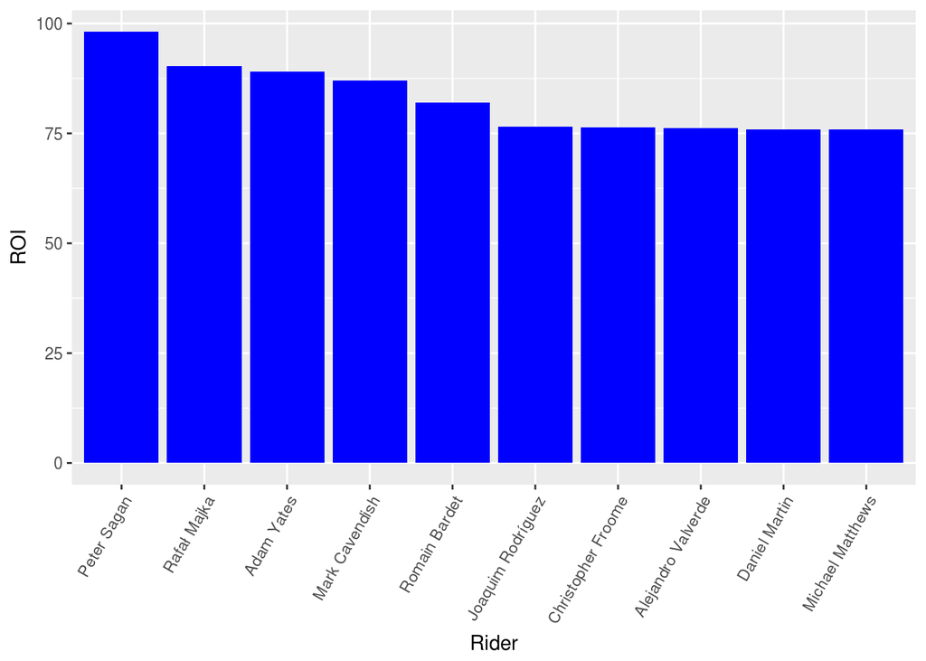

The ROI data is insightful in that it reveals which riders provided the best bang for buck. Although expensive picks such as Sagan ultimately proved good investments, teams backing Adan Yates must have been cheering all the way to the Velocredit bank!

### Overall Team Performance

At the end of a tightly fought three week battle the Jackal took top step on the podium by an extremely slim margin over Fiorini’s Old Tricks. However it required bonus point allocations on the final stage for Andrew’s team to unseat Chris’ old boys who had essentially led from start to finish and seemed destined for victory.

| Team | Directeur | Total |
| --- | --- | --- |
| Team Tarmac | Jackal | 6296 |
| 4051 New Tricks | Chris Fiorini | 6256 |
| Leggo’s Legovers | David Leggett | 5518 |
| Ferris Wheel | Jeffrey Beehler | 5474 |
| $10 Legs | Jamie Forster | 5237 |
| Shut Up Legs | Steve Kelsall | 5013 |
| Wilston Wippets | Peter Howes | 4958 |
| Tour de Forster 2016 | Mandy Forster | 4913 |
| Flamme Rouge Flyers | David Pink | 4826 |
| Itchy Nads | Daniel Lewis | 4565 |
| Mick`s Dumpster Divers | Mick Groom | 4498 |
| Truffle Snufflers | MattCrooky | 4417 |
| Thistles | Simon Scott | 4282 |
| Brake Rub Regression | Simon Lyons | 3744 |

### Individual Stage Performance

The scores for each stage paint a picture of early success for the team of Old Tricks.

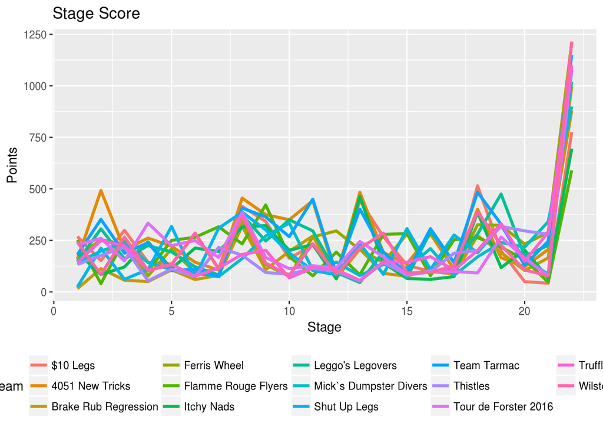

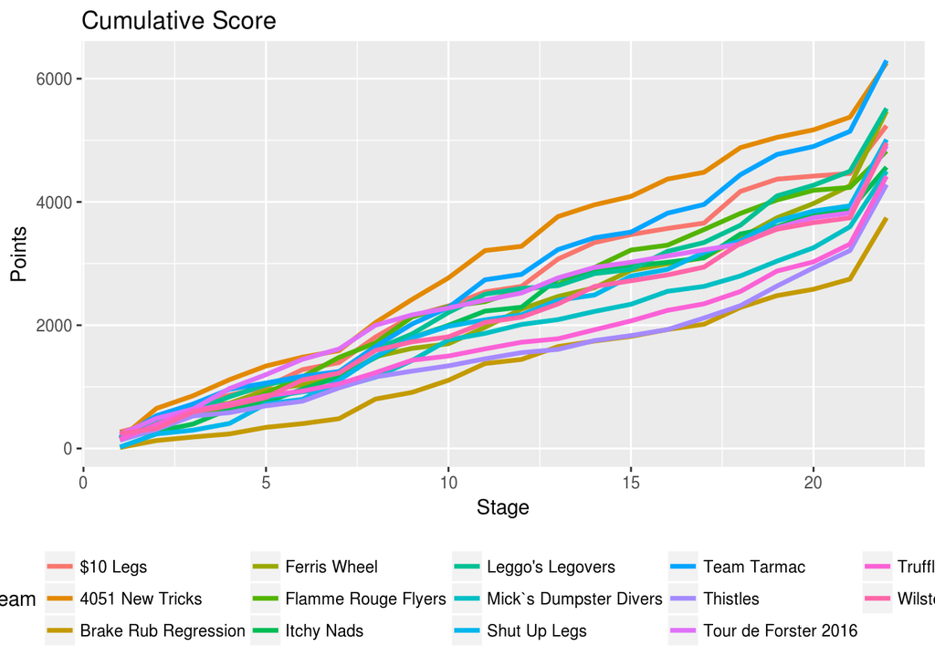

The top teams all had Peter Sagan, combined with either Chris Froome or Romain Bardet.

| Team | Rider | Rider Total |
| --- | --- | --- |
| 4051 New Tricks | Christopher Froome | 1985 |
| 4051 New Tricks | Peter Sagan | 1963 |
| 4051 New Tricks | Daniel Martin | 911 |
| 4051 New Tricks | Tom Dumoulin | 644 |
| Leggo’s Legovers | Peter Sagan | 1963 |
| Leggo’s Legovers | Romain Bardet | 1148 |
| Leggo’s Legovers | Joaquim Rodríguez | 919 |
| Leggo’s Legovers | Richie Porte | 776 |
| Team Tarmac | Christopher Froome | 1985 |
| Team Tarmac | Peter Sagan | 1963 |
| Team Tarmac | Romain Bardet | 1148 |
| Team Tarmac | Tom Dumoulin | 644 |

| Team | Rider | Rider Total |
| --- | --- | --- |
| Brake Rub Regression | Christopher Froome | 1985 |
| Brake Rub Regression | Nairo Quintana | 1028 |
| Brake Rub Regression | Edvald Boasson Hagen | 393 |
| Brake Rub Regression | Imanol Erviti | 140 |
| Thistles | Alejandro Valverde | 1067 |
| Thistles | Nairo Quintana | 1028 |
| Thistles | Richie Porte | 776 |
| Thistles | André Greipel | 727 |
| Truffle Snufflers | Alejandro Valverde | 1067 |
| Truffle Snufflers | Nairo Quintana | 1028 |
| Truffle Snufflers | Richie Porte | 776 |
| Truffle Snufflers | André Greipel | 727 |

Perhaps there’s some lessons in there as you look to finalise your squads for this year’s Tour. Get your team in before the cutoff early this evening!